# Doing Data Science: Case Study

Claire Chu

June 19, 2016

# R Code and Analysis for Unit 6 Case Study

### PRELIMINARY STEPS

##### Load the following packages.

```r
library(downloader)
library(repmis)
library(RCurl)
library(dplyr)
library(plyr)
library(tidyr)
library(ggplot2)
setwd("/Users/macnificent/Desktop")
```

# I. INTRODUCTION TO THE PROBLEM

##### We will explore two datasets; one that details the GDP rankings worldwide and another which details various income statistics for countries around the world. Both datasets will be downloaded raw from http://data.worldbank.org/data-catalog and munged with the code that follows. Once cleaned, we will focus our analysis on the GDP rankings and Income groupings for the top 190 countries worldwide.

# II. DOWNLOAD THE FILES

##### Download the data from the provided links.

```r
site <- "https://d396qusza40orc.cloudfront.net/getdata%2Fdata%2FGDP.csv"
download.file(site, destfile = "./GDP.csv")
site <- "https://d396qusza40orc.cloudfront.net/getdata%2Fdata%2FEDSTATS_Country.csv"
download.file(site, destfile = "./educ.csv")
```

```
## Data downloaded to local file
```

# III. READ THE FILES

##### Work through reading in the GDP dataset.

```r
GDP <- read.csv("GDP.csv")
head(GDP,10)
```

```
##      X Gross.domestic.product.2012 X.1            X.2          X.3 X.4 X.5
## 1                                   NA                                  NA
## 2                                   NA                (millions of      NA
## 3                          Ranking  NA        Economy  US dollars)      NA
## 4                                   NA                                  NA
## 5  USA                           1  NA  United States  16,244,600       NA
## 6  CHN                           2  NA          China   8,227,103       NA
## 7  JPN                           3  NA          Japan   5,959,718       NA
## 8  DEU                           4  NA        Germany   3,428,131       NA
## 9  FRA                           5  NA         France   2,612,878       NA
## 10 GBR                           6  NA United Kingdom   2,471,784       NA
##    X.6 X.7 X.8
## 1   NA  NA  NA
## 2   NA  NA  NA
## 3   NA  NA  NA
## 4   NA  NA  NA
## 5   NA  NA  NA
## 6   NA  NA  NA
## 7   NA  NA  NA
## 8   NA  NA  NA
## 9   NA  NA  NA
## 10  NA  NA  NA
```

##### It appears that the first 4 rows may be a header, with the column names listed in rows 2-3. we can also see that columns 4-10 may consist of “NA” columns.

```r
GDP <- read.csv("GDP.csv", stringsAsFactors=FALSE, header=FALSE)
head(GDP,10)
```

```
##     V1                          V2 V3            V4           V5 V6 V7 V8
## 1      Gross domestic product 2012 NA                               NA NA
## 2                                  NA                               NA NA
## 3                                  NA               (millions of    NA NA
## 4                          Ranking NA       Economy  US dollars)    NA NA
## 5                                  NA                               NA NA
## 6  USA                           1 NA United States  16,244,600     NA NA
## 7  CHN                           2 NA         China   8,227,103     NA NA
## 8  JPN                           3 NA         Japan   5,959,718     NA NA
## 9  DEU                           4 NA       Germany   3,428,131     NA NA
## 10 FRA                           5 NA        France   2,612,878     NA NA
##    V9 V10
## 1  NA  NA
## 2  NA  NA
## 3  NA  NA
## 4  NA  NA
## 5  NA  NA
## 6  NA  NA
## 7  NA  NA
## 8  NA  NA
## 9  NA  NA
## 10 NA  NA
```

##### Let’s look at a data overview.

```r
str(GDP)
```

```
## 'data.frame':    331 obs. of  10 variables:
##  $ V1 : chr  "" "" "" "" ...
##  $ V2 : chr  "Gross domestic product 2012" "" "" "Ranking" ...
##  $ V3 : logi  NA NA NA NA NA NA ...
##  $ V4 : chr  "" "" "" "Economy" ...
##  $ V5 : chr  "" "" "(millions of" "US dollars)" ...
##  $ V6 : chr  "" "" "" "" ...
##  $ V7 : logi  NA NA NA NA NA NA ...
##  $ V8 : logi  NA NA NA NA NA NA ...
##  $ V9 : logi  NA NA NA NA NA NA ...
##  $ V10: logi  NA NA NA NA NA NA ...
```

##### We can see there are 331 observations and 10 variables.

```r
GDPdata <- GDP[6:195, 1:5]
```

##### This is to eliminate the “header” that was row 1-5, only take the requested top 190 countries and the empty “NA” columns 5-10.

```r
head(GDPdata)
```

```
##     V1 V2 V3             V4           V5
## 6  USA  1 NA  United States  16,244,600
## 7  CHN  2 NA          China   8,227,103
## 8  JPN  3 NA          Japan   5,959,718
## 9  DEU  4 NA        Germany   3,428,131
## 10 FRA  5 NA         France   2,612,878
## 11 GBR  6 NA United Kingdom   2,471,784
```

```
## GDP Data ready for cleaning
```

##### Work through reading in the EDUCATION & INCOME dataset.

```r
edu <- read.csv("educ.csv")
head(edu, 5)
```

```
##   CountryCode                    Long.Name         Income.Group
## 1         ABW                        Aruba High income: nonOECD
## 2         ADO      Principality of Andorra High income: nonOECD
## 3         AFG Islamic State of Afghanistan           Low income
## 4         AGO  People's Republic of Angola  Lower middle income
## 5         ALB          Republic of Albania  Upper middle income
##                      Region Lending.category Other.groups  Currency.Unit
## 1 Latin America & Caribbean                                Aruban florin
## 2     Europe & Central Asia                                         Euro
## 3                South Asia              IDA         HIPC Afghan afghani
## 4        Sub-Saharan Africa              IDA              Angolan kwanza
## 5     Europe & Central Asia             IBRD                Albanian lek
##   Latest.population.census  Latest.household.survey
## 1                     2000
## 2           Register based
## 3                     1979               MICS, 2003
## 4                     1970 MICS, 2001, MIS, 2006/07
## 5                     2001               MICS, 2005
##                                                                 Special.Notes
## 1
## 2
## 3 Fiscal year end: March 20; reporting period for national accounts data: FY.
## 4
## 5
##   National.accounts.base.year National.accounts.reference.year
## 1                        1995                               NA
## 2                                                           NA
## 3                   2002/2003                               NA
## 4                        1997                               NA
## 5                                                         1996
##   System.of.National.Accounts SNA.price.valuation
## 1                          NA
## 2                          NA
## 3                          NA                 VAB
## 4                          NA                 VAP
## 5                        1993                 VAB
##   Alternative.conversion.factor PPP.survey.year
## 1                                            NA
## 2                                            NA
## 3                                            NA
```

[output cut: 29 more lines]

```
## 3
## 4                                                1964-65
## 5                         Yes                       1998
##   Latest.industrial.data Latest.trade.data Latest.water.withdrawal.data
## 1                     NA              2008                           NA
## 2                     NA              2006                           NA
## 3                     NA              2008                         2000
## 4                     NA              1991                         2000
## 5                   2005              2008                         2000
##   X2.alpha.code WB.2.code  Table.Name  Short.Name
## 1            AW        AW       Aruba       Aruba
## 2            AD        AD     Andorra     Andorra
## 3            AF        AF Afghanistan Afghanistan
## 4            AO        AO      Angola      Angola
## 5            AL        AL     Albania     Albania
```

##### It appears that there are column names in row one.

```r
edu <- read.csv("educ.csv", stringsAsFactors=FALSE, header=TRUE)
```

##### Let’s look at a data overview. We can see there are 234 observations and 31 variables.

```r
str(edu)
```

```
## 'data.frame':    234 obs. of  31 variables:
##  $ CountryCode                                      : chr  "ABW" "ADO" "AFG" "AGO" ...
##  $ Long.Name                                        : chr  "Aruba" "Principality of Andorra" "Islamic State of Afghanistan" "People's Republic of Angola" ...
##  $ Income.Group                                     : chr  "High income: nonOECD" "High income: nonOECD" "Low income" "Lower middle income" ...
##  $ Region                                           : chr  "Latin America & Caribbean" "Europe & Central Asia" "South Asia" "Sub-Saharan Africa" ...
##  $ Lending.category                                 : chr  "" "" "IDA" "IDA" ...
##  $ Other.groups                                     : chr  "" "" "HIPC" "" ...
##  $ Currency.Unit                                    : chr  "Aruban florin" "Euro" "Afghan afghani" "Angolan kwanza" ...
##  $ Latest.population.census                         : chr  "2000" "Register based" "1979" "1970" ...
##  $ Latest.household.survey                          : chr  "" "" "MICS, 2003" "MICS, 2001, MIS, 2006/07" ...
##  $ Special.Notes                                    : chr  "" "" "Fiscal year end: March 20; reporting period for national accounts data: FY." "" ...
##  $ National.accounts.base.year                      : chr  "1995" "" "2002/2003" "1997" ...
##  $ National.accounts.reference.year                 : int  NA NA NA NA 1996 NA NA 1996 NA NA ...
##  $ System.of.National.Accounts                      : int  NA NA NA NA 1993 NA 1993 1993 NA NA ...
##  $ SNA.price.valuation                              : chr  "" "" "VAB" "VAP" ...
```

[output cut: 17 more lines]

```
## Education Data ready for cleaning
```

# IV. CLEAN THE DATA

##### Clean up the GDP dataset.

```r
head(GDPdata)
```

```
##     V1 V2 V3             V4           V5
## 6  USA  1 NA  United States  16,244,600
## 7  CHN  2 NA          China   8,227,103
## 8  JPN  3 NA          Japan   5,959,718
## 9  DEU  4 NA        Germany   3,428,131
## 10 FRA  5 NA         France   2,612,878
## 11 GBR  6 NA United Kingdom   2,471,784
```

```r
names(GDPdata) <- c ("CountryCode", "GDPRanking","notsure", "CountryName","GDP")
```

##### Generate column names, we can see column 3 doesn’t have an understandable name.

```r
head(GDPdata)
```

```
##    CountryCode GDPRanking notsure    CountryName          GDP
## 6          USA          1      NA  United States  16,244,600
## 7          CHN          2      NA          China   8,227,103
## 8          JPN          3      NA          Japan   5,959,718
## 9          DEU          4      NA        Germany   3,428,131
## 10         FRA          5      NA         France   2,612,878
## 11         GBR          6      NA United Kingdom   2,471,784
```

##### Let’s investigate the “notsure” column.

```r
GDPdata$notsure
```

```
##   [1] NA NA NA NA NA NA NA NA NA NA NA NA NA NA NA NA NA NA NA NA NA NA NA
##  [24] NA NA NA NA NA NA NA NA NA NA NA NA NA NA NA NA NA NA NA NA NA NA NA
##  [47] NA NA NA NA NA NA NA NA NA NA NA NA NA NA NA NA NA NA NA NA NA NA NA
##  [70] NA NA NA NA NA NA NA NA NA NA NA NA NA NA NA NA NA NA NA NA NA NA NA
##  [93] NA NA NA NA NA NA NA NA NA NA NA NA NA NA NA NA NA NA NA NA NA NA NA
## [116] NA NA NA NA NA NA NA NA NA NA NA NA NA NA NA NA NA NA NA NA NA NA NA
## [139] NA NA NA NA NA NA NA NA NA NA NA NA NA NA NA NA NA NA NA NA NA NA NA
## [162] NA NA NA NA NA NA NA NA NA NA NA NA NA NA NA NA NA NA NA NA NA NA NA
## [185] NA NA NA NA NA NA
```

##### They are all “NA” so let’s remove them.

```r
GDPdata2 <- GDPdata[ ,c("CountryCode", "GDPRanking", "CountryName", "GDP")]
head(GDPdata2)
```

```
##    CountryCode GDPRanking    CountryName          GDP
## 6          USA          1  United States  16,244,600
## 7          CHN          2          China   8,227,103
## 8          JPN          3          Japan   5,959,718
## 9          DEU          4        Germany   3,428,131
## 10         FRA          5         France   2,612,878
## 11         GBR          6 United Kingdom   2,471,784
```

```r
summary(GDPdata2)
```

```
##  CountryCode         GDPRanking        CountryName
##  Length:190         Length:190         Length:190
##  Class :character   Class :character   Class :character
##  Mode  :character   Mode  :character   Mode  :character
##      GDP
##  Length:190
##  Class :character
##  Mode  :character
```

##### Check for any additional “NA”

```r
count(is.na(GDPdata2))
```

```
##   x.CountryCode x.GDPRanking x.CountryName x.GDP freq
## 1         FALSE        FALSE         FALSE FALSE  190
```

##### Remove commas in the GDP category and convert them to numeric entries so we can run analysis.

```r
GDPnum <- as.numeric(gsub(",", "", GDPdata2$GDP))
GDPdata2$GDPnew <- GDPnum
head(GDPdata2)
```

```
##    CountryCode GDPRanking    CountryName          GDP   GDPnew
## 6          USA          1  United States  16,244,600  16244600
## 7          CHN          2          China   8,227,103   8227103
## 8          JPN          3          Japan   5,959,718   5959718
## 9          DEU          4        Germany   3,428,131   3428131
## 10         FRA          5         France   2,612,878   2612878
## 11         GBR          6 United Kingdom   2,471,784   2471784
```

##### Remove the old GDP column.

```r
GDPdata3 <- GDPdata2[ ,c("CountryCode", "GDPRanking", "CountryName", "GDPnew")]
head(GDPdata3)
```

```
##    CountryCode GDPRanking    CountryName   GDPnew
## 6          USA          1  United States 16244600
## 7          CHN          2          China  8227103
## 8          JPN          3          Japan  5959718
## 9          DEU          4        Germany  3428131
## 10         FRA          5         France  2612878
## 11         GBR          6 United Kingdom  2471784
```

##### Clean up the EDUCATION & INCOME dataset.

##### Lets investigate these column names.

```r
names(edu)
```

```
##  [1] "CountryCode"
##  [2] "Long.Name"
##  [3] "Income.Group"
##  [4] "Region"
##  [5] "Lending.category"
##  [6] "Other.groups"
##  [7] "Currency.Unit"
##  [8] "Latest.population.census"
##  [9] "Latest.household.survey"
## [10] "Special.Notes"
## [11] "National.accounts.base.year"
## [12] "National.accounts.reference.year"
## [13] "System.of.National.Accounts"
## [14] "SNA.price.valuation"
## [15] "Alternative.conversion.factor"
```

[output cut: 16 more lines]

##### Based on the column names, we can eliminate some of the excess data.

```r
EDUdata <- edu[ ,c("CountryCode", "Long.Name", "Income.Group", "Region", "Short.Name")]
summary(EDUdata)
```

```
##  CountryCode         Long.Name         Income.Group
##  Length:234         Length:234         Length:234
##  Class :character   Class :character   Class :character
##  Mode  :character   Mode  :character   Mode  :character
##     Region           Short.Name
##  Length:234         Length:234
##  Class :character   Class :character
##  Mode  :character   Mode  :character
```

##### We suspect there are something going on in the “Income.Group” column.

```r
EDUdata$Income.Group[1:60]
```

```
##  [1] "High income: nonOECD" "High income: nonOECD" "Low income"
##  [4] "Lower middle income"  "Upper middle income"  "High income: nonOECD"
##  [7] "Upper middle income"  "Lower middle income"  "Upper middle income"
## [10] "Upper middle income"  "High income: OECD"    "High income: OECD"
## [13] "Upper middle income"  "Low income"           "High income: OECD"
## [16] "Low income"           "Low income"           "Low income"
## [19] "Upper middle income"  "High income: nonOECD" "High income: nonOECD"
## [22] "Upper middle income"  "Upper middle income"  "Lower middle income"
## [25] "High income: nonOECD" "Lower middle income"  "Upper middle income"
## [28] "High income: nonOECD" "High income: nonOECD" "Lower middle income"
## [31] "Upper middle income"  "Low income"           "High income: OECD"
## [34] "High income: OECD"    "High income: nonOECD" "Upper middle income"
## [37] "Lower middle income"  "Lower middle income"  "Lower middle income"
## [40] "Lower middle income"  "Upper middle income"  "Low income"
## [43] "Lower middle income"  "Upper middle income"  "Upper middle income"
## [46] "High income: nonOECD" "High income: nonOECD" "High income: OECD"
## [49] "High income: OECD"    "Lower middle income"  "Upper middle income"
## [52] "High income: OECD"    "Upper middle income"  "Upper middle income"
## [55] ""                     ""                     ""
## [58] ""                     "Lower middle income"  "Lower middle income"
```

##### Instead of traditional “NA”, there are some blank entries in the column. Let’s remove these and sort the dataset by income group so that all the blank entries are at the end.

```r
EDUdata2 <- arrange(EDUdata,desc(Income.Group))
```

##### After sorting, it seems like the blank entries begin at row 211. Lets remove them.

```r
EDUdata3 <- EDUdata2 [1:210, ]
```

##### Check for any “NA” in the dataset.

```r
count(is.na(EDUdata3))
```

```
##   x.CountryCode x.Long.Name x.Income.Group x.Region x.Short.Name freq
## 1         FALSE       FALSE          FALSE    FALSE        FALSE  210
```

```r
summary(EDUdata3)
```

```
##  CountryCode         Long.Name         Income.Group
##  Length:210         Length:210         Length:210
##  Class :character   Class :character   Class :character
##  Mode  :character   Mode  :character   Mode  :character
##     Region           Short.Name
##  Length:210         Length:210
##  Class :character   Class :character
##  Mode  :character   Mode  :character
```

```r
summary(GDPdata3)
```

```
##  CountryCode         GDPRanking        CountryName
##  Length:190         Length:190         Length:190
##  Class :character   Class :character   Class :character
##  Mode  :character   Mode  :character   Mode  :character
##
##
##
##      GDPnew
##  Min.   :      40
##  1st Qu.:    7005
##  Median :   27638
##  Mean   :  377652
##  3rd Qu.:  205289
##  Max.   :16244600
```

```
## Data is ready for Merging!
```

# V. MERGE DATA

```r
cleanGDPmerge <- merge(GDPdata3, EDUdata3, by="CountryCode", all=TRUE)
head(cleanGDPmerge)
```

```
##   CountryCode GDPRanking          CountryName GDPnew
## 1         ABW        161                Aruba   2584
## 2         ADO       <NA>                 <NA>     NA
## 3         AFG        105          Afghanistan  20497
## 4         AGO         60               Angola 114147
## 5         ALB        125              Albania  12648
## 6         ARE         32 United Arab Emirates 348595
##                      Long.Name         Income.Group
## 1                        Aruba High income: nonOECD
## 2      Principality of Andorra High income: nonOECD
## 3 Islamic State of Afghanistan           Low income
## 4  People's Republic of Angola  Lower middle income
## 5          Republic of Albania  Upper middle income
## 6         United Arab Emirates High income: nonOECD
##                       Region           Short.Name
## 1  Latin America & Caribbean                Aruba
## 2      Europe & Central Asia              Andorra
## 3                 South Asia          Afghanistan
## 4         Sub-Saharan Africa               Angola
## 5      Europe & Central Asia              Albania
## 6 Middle East & North Africa United Arab Emirates
```

```r
summary(cleanGDPmerge)
```

```
##  CountryCode         GDPRanking        CountryName
##  Length:211         Length:211         Length:211
##  Class :character   Class :character   Class :character
##  Mode  :character   Mode  :character   Mode  :character
##
##
##
##
##      GDPnew          Long.Name         Income.Group
##  Min.   :      40   Length:211         Length:211
##  1st Qu.:    7005   Class :character   Class :character
##  Median :   27638   Mode  :character   Mode  :character
##  Mean   :  377652
##  3rd Qu.:  205289
##  Max.   :16244600
##  NA's   :21
##     Region           Short.Name
##  Length:211         Length:211
##  Class :character   Class :character
##  Mode  :character   Mode  :character
##
##
##
##
```

##### Check to see if there were any NAs generated from the merge.

```r
count(is.na(cleanGDPmerge))
```

```
##   x.CountryCode x.GDPRanking x.CountryName x.GDPnew x.Long.Name
## 1         FALSE        FALSE         FALSE    FALSE       FALSE
## 2         FALSE        FALSE         FALSE    FALSE        TRUE
## 3         FALSE         TRUE          TRUE     TRUE       FALSE
##   x.Income.Group x.Region x.Short.Name freq
## 1          FALSE    FALSE        FALSE  189
## 2           TRUE     TRUE         TRUE    1
## 3          FALSE    FALSE        FALSE   21
```

##### We’ve got some NAs, let’s investigate to see where they exist.

```r
count(is.na(cleanGDPmerge$CountryCode))
```

```
##       x freq
## 1 FALSE  211
```

```r
count(is.na(cleanGDPmerge$GDPRanking))
```

```
##       x freq
## 1 FALSE  190
## 2  TRUE   21
```

```r
count(is.na(cleanGDPmerge$CountryName))
```

```
##       x freq
## 1 FALSE  190
## 2  TRUE   21
```

```r
count(is.na(cleanGDPmerge$GDPnew))
```

```
##       x freq
## 1 FALSE  190
## 2  TRUE   21
```

```r
count(is.na(cleanGDPmerge$Long.Name))
```

```
##       x freq
## 1 FALSE  210
## 2  TRUE    1
```

```r
count(is.na(cleanGDPmerge$Income.Group))
```

```
##       x freq
## 1 FALSE  210
## 2  TRUE    1
```

```r
count(is.na(cleanGDPmerge$Region))
```

```
##       x freq
## 1 FALSE  210
## 2  TRUE    1
```

```r
count(is.na(cleanGDPmerge$Short.Name))
```

```
##       x freq
## 1 FALSE  210
## 2  TRUE    1
```

##### These results make sense since the columns from the GDP dataset only had 190 values, the columns for the EDU dataset had 210 so there should be about 20 rows with “NA”. Let’s remove the rows where there is an “NA” in GDP ranking.

```r
cleanGDPmerge2 <- arrange(cleanGDPmerge,desc(GDPRanking))
cleanGDPmerge3 <- cleanGDPmerge2 [1:190, ]
summary(cleanGDPmerge3)
```

```
##  CountryCode         GDPRanking        CountryName
##  Length:190         Length:190         Length:190
##  Class :character   Class :character   Class :character
##  Mode  :character   Mode  :character   Mode  :character
##
##
##
##      GDPnew          Long.Name         Income.Group
##  Min.   :      40   Length:190         Length:190
##  1st Qu.:    7005   Class :character   Class :character
##  Median :   27638   Mode  :character   Mode  :character
##  Mean   :  377652
##  3rd Qu.:  205289
##  Max.   :16244600
##     Region           Short.Name
##  Length:190         Length:190
##  Class :character   Class :character
##  Mode  :character   Mode  :character
##
##
##
```

##### Now check again for “NA”.

```r
count(is.na(cleanGDPmerge3))
```

```
##   x.CountryCode x.GDPRanking x.CountryName x.GDPnew x.Long.Name
## 1         FALSE        FALSE         FALSE    FALSE       FALSE
## 2         FALSE        FALSE         FALSE    FALSE        TRUE
##   x.Income.Group x.Region x.Short.Name freq
## 1          FALSE    FALSE        FALSE  189
## 2           TRUE     TRUE         TRUE    1
```

##### It seems there is one NA from an entry that existed in the GDP data but not in the EDU data. Lets find it and investigate.

```r
which(is.na(cleanGDPmerge3$Long.Name))
```

```
## [1] 154
```

```r
cleanGDPmerge3[154,]
```

```
##     CountryCode GDPRanking CountryName GDPnew Long.Name Income.Group
## 154         SSD        131 South Sudan  10220      <NA>         <NA>
##     Region Short.Name
## 154   <NA>       <NA>
```

##### We should be cautious about removing this one since it is a GDP ranking. We can see that the “NA” exists in the “Income.Group” classification. Since we would like to maintain the consistency of the GDP Ranks, let’s leave it for now. Note: Any “Income.Group” exploration will require the removal of this entry.

```r
summary(cleanGDPmerge3)
```

```
##  CountryCode         GDPRanking        CountryName
##  Length:190         Length:190         Length:190
##  Class :character   Class :character   Class :character
##  Mode  :character   Mode  :character   Mode  :character
##
##
##
##      GDPnew          Long.Name         Income.Group
##  Min.   :      40   Length:190         Length:190
##  1st Qu.:    7005   Class :character   Class :character
##  Median :   27638   Mode  :character   Mode  :character
##  Mean   :  377652
##  3rd Qu.:  205289
##  Max.   :16244600
##     Region           Short.Name
##  Length:190         Length:190
##  Class :character   Class :character
##  Mode  :character   Mode  :character
##
##
##
```

```
## Data is ready for Analysis
```

# VI. ANALYZE DATA

### QUESTION 1

##### How many of the IDs Match?

```r
summary(cleanGDPmerge)
```

```
##  CountryCode         GDPRanking        CountryName
##  Length:211         Length:211         Length:211
##  Class :character   Class :character   Class :character
##  Mode  :character   Mode  :character   Mode  :character
##
##
##
##
##      GDPnew          Long.Name         Income.Group
##  Min.   :      40   Length:211         Length:211
##  1st Qu.:    7005   Class :character   Class :character
##  Median :   27638   Mode  :character   Mode  :character
##  Mean   :  377652
##  3rd Qu.:  205289
##  Max.   :16244600
##  NA's   :21
##     Region           Short.Name
##  Length:211         Length:211
##  Class :character   Class :character
##  Mode  :character   Mode  :character
##
##
##
##
```

```r
duplicated(cleanGDPmerge)
```

```
##   [1] FALSE FALSE FALSE FALSE FALSE FALSE FALSE FALSE FALSE FALSE FALSE
##  [12] FALSE FALSE FALSE FALSE FALSE FALSE FALSE FALSE FALSE FALSE FALSE
##  [23] FALSE FALSE FALSE FALSE FALSE FALSE FALSE FALSE FALSE FALSE FALSE
##  [34] FALSE FALSE FALSE FALSE FALSE FALSE FALSE FALSE FALSE FALSE FALSE
##  [45] FALSE FALSE FALSE FALSE FALSE FALSE FALSE FALSE FALSE FALSE FALSE
##  [56] FALSE FALSE FALSE FALSE FALSE FALSE FALSE FALSE FALSE FALSE FALSE
##  [67] FALSE FALSE FALSE FALSE FALSE FALSE FALSE FALSE FALSE FALSE FALSE
##  [78] FALSE FALSE FALSE FALSE FALSE FALSE FALSE FALSE FALSE FALSE FALSE
##  [89] FALSE FALSE FALSE FALSE FALSE FALSE FALSE FALSE FALSE FALSE FALSE
## [100] FALSE FALSE FALSE FALSE FALSE FALSE FALSE FALSE FALSE FALSE FALSE
## [111] FALSE FALSE FALSE FALSE FALSE FALSE FALSE FALSE FALSE FALSE FALSE
## [122] FALSE FALSE FALSE FALSE FALSE FALSE FALSE FALSE FALSE FALSE FALSE
## [133] FALSE FALSE FALSE FALSE FALSE FALSE FALSE FALSE FALSE FALSE FALSE
## [144] FALSE FALSE FALSE FALSE FALSE FALSE FALSE FALSE FALSE FALSE FALSE
## [155] FALSE FALSE FALSE FALSE FALSE FALSE FALSE FALSE FALSE FALSE FALSE
## [166] FALSE FALSE FALSE FALSE FALSE FALSE FALSE FALSE FALSE FALSE FALSE
## [177] FALSE FALSE FALSE FALSE FALSE FALSE FALSE FALSE FALSE FALSE FALSE
## [188] FALSE FALSE FALSE FALSE FALSE FALSE FALSE FALSE FALSE FALSE FALSE
## [199] FALSE FALSE FALSE FALSE FALSE FALSE FALSE FALSE FALSE FALSE FALSE
## [210] FALSE FALSE
```

##### We know that the first dataset had 190 rows and the second dataset had 210 rows and there are no duplicates, we know that one entry in the GDP countrycode that did not exist in the EDU countrycode column. Therefore, we had 189 matched out of 190. Our only countrycode that did not match was row 154 “South Sudan”. We can tell this is the case since, all the columns from the EDU dataset for this row are “NA”.

### QUESTION 2

###### Sort the data frame in ascending order by GDP rank. What is the 13th country in the data frame?

##### First, we need to transpose the GDPRanking column into integers so we can sort them.

```r
cleanGDPmerge3$GDPRanking <- as.integer(cleanGDPmerge3$GDPRanking)
cleanGDPmergeRANK <- arrange(cleanGDPmerge3, desc(GDPRanking))
```

##### Look up the 13th row.

```r
cleanGDPmergeRANK[13,]
```

```
##    CountryCode GDPRanking         CountryName GDPnew           Long.Name
## 13         KNA        178 St. Kitts and Nevis    767 St. Kitts and Nevis
##           Income.Group                    Region          Short.Name
## 13 Upper middle income Latin America & Caribbean St. Kitts and Nevis
```

```
## It appears that the country ST. KITTS AND NEVIS ranks 178 in GDP
```

### QUESTION 3

##### What are the average GDP Rankings for the “High Income: OECD” and “High Income: nonOECD” groups.

```r
cleanGDPmergeINC <- arrange(cleanGDPmerge3,desc(Income.Group))
```

##### we can see that the “high income: OECD” group exists at [137:166, ] and “high income: nonOECD”" exists at [167:189, ].

##### Let’s put these into their own data frames.

```r
HighIncOECD <- cleanGDPmergeINC[137:166, ]
HighIncNonOECD <- cleanGDPmergeINC[167:189, ]
```

```r
summary(HighIncOECD)
```

```
##  CountryCode          GDPRanking     CountryName            GDPnew
##  Length:30          Min.   :  1.00   Length:30          Min.   :   13579
##  Class :character   1st Qu.: 12.25   Class :character   1st Qu.:  211147
##  Mode  :character   Median : 24.50   Mode  :character   Median :  486528
##                     Mean   : 32.97                      Mean   : 1483917
##                     3rd Qu.: 45.75                      3rd Qu.: 1480047
##                     Max.   :122.00                      Max.   :16244600
##   Long.Name         Income.Group          Region
##  Length:30          Length:30          Length:30
##  Class :character   Class :character   Class :character
##  Mode  :character   Mode  :character   Mode  :character
##
##
##
##   Short.Name
##  Length:30
##  Class :character
##  Mode  :character
##
##
##
```

```r
summary(HighIncNonOECD)
```

```
##  CountryCode          GDPRanking     CountryName            GDPnew
##  Length:23          Min.   : 19.00   Length:23          Min.   :  2584
##  Class :character   1st Qu.: 58.50   Class :character   1st Qu.: 12838
##  Mode  :character   Median : 94.00   Mode  :character   Median : 28373
##                     Mean   : 91.91                      Mean   :104350
##                     3rd Qu.:125.00                      3rd Qu.:131204
##                     Max.   :161.00                      Max.   :711050
##   Long.Name         Income.Group          Region
##  Length:23          Length:23          Length:23
##  Class :character   Class :character   Class :character
##  Mode  :character   Mode  :character   Mode  :character
##
##
##
##   Short.Name
##  Length:23
##  Class :character
##  Mode  :character
##
##
##
```

```
## The Average GDP ranking for High Income: OECD is 32.97.
```

```
## The Average GDP for High Income: OECD is $1,483,917.
```

```
## The Average GDP ranking for High Income: Non OECD is 91.91.
```

```
## The Average GDP for High Income:Non OECD is $104,350.
```

### QUESTION 4

##### Plot the GDP for all the countries. Use ggplot2 to color your plot by Income Group.

##### Let’s being by pulling out info we will use for graph. We want the plot to display countries in their rank order.

```r
graphGDPdata <- cleanGDPmergeRANK[ ,c("CountryCode", "GDPnew", "Income.Group")]
```

##### Remove the South Sudan “income.group” “NA” entry.

```r
graphGDPdata <- graphGDPdata[-60,]
```

##### Set up the parameters for graphGDP. We need to make sure the country code stays in the same order, otherwise, qqplot will plot alphabetically.

```r
graphGDP <- ggplot(graphGDPdata, aes(reorder(CountryCode, GDPnew), GDPnew))
```

##### Construct a scatter plot with GDP on the y axis and Country Code ranked by GDP in ascending order, that the points are color coded according to income group, make sure to scale the y axis by log10 and specify the names of axis and legend position.

```r
graphGDPpoint <- graphGDP + geom_point(aes(colour = Income.Group)) + theme(axis.text.x = element_blank()) + scale_y_log10(labels = NULL) + labs(title = "Top 190 GDPs by Country", x = "Countries in Ascending GDP Rank", y = "GDP (Transformed with log10)") + theme(legend.position = "bottom")
```

##### Generate the scatter plot.

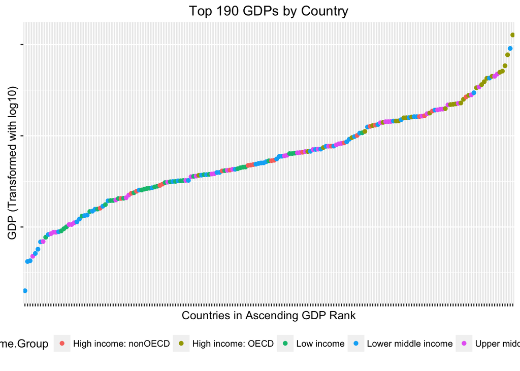

```r
graphGDPpoint
```

##### We can see that with the country data plotted in ascending order by GDP, that our results from Question 3 are accurate. Most of the top ranked countries are from the High Income: OECD class, as mentioned by their average ranking. It is also important to note that the Low Income group is very poorly represented in the top ranks. In fact, the first green point to represent Low Income seems to be located outside the top 25%.

##### Note: The country of South Sudan contains an “NA” value, in the “income.group” classification. This is because it existed in the pre-merge GDP dataset, but not in the pre-merge EDU dataset. Because of this, it has been removed from this graph as it requires income group classification, but left it in the table below exploring “GDP Rank”.

### QUESTION 5

##### Cut the GDP ranking into 5 quantile groups. make a table versus Income Group. How many countries are Lower Middle income but among the 38 nations with the highest GDP?

##### Let’s first look at the ranking quantiles.

```r
summary(cleanGDPmerge3)
```

```
##  CountryCode          GDPRanking     CountryName            GDPnew
##  Length:190         Min.   :  1.00   Length:190         Min.   :      40
##  Class :character   1st Qu.: 48.25   Class :character   1st Qu.:    7005
##  Mode  :character   Median : 95.50   Mode  :character   Median :   27638
##                     Mean   : 95.49                      Mean   :  377652
##                     3rd Qu.:142.75                      3rd Qu.:  205289
##                     Max.   :190.00                      Max.   :16244600
##   Long.Name         Income.Group          Region
##  Length:190         Length:190         Length:190
##  Class :character   Class :character   Class :character
##  Mode  :character   Mode  :character   Mode  :character
##
##
##
##   Short.Name
##  Length:190
##  Class :character
##  Mode  :character
##
##
##
```

##### The quantiles are defined by 1, 48.25, 95.5, 142.75, 190.

##### Let’s slice data according to quantile groups. We will use the cleanGDPmergeRANK data since these are already in order of rank. We have be careful since it is organized in ASCENDING order!

```r
FirstQuantileGDPRank <- cleanGDPmergeRANK [144:190, ]
```

##### Pull only the columns we are interested in to simplify the data.

```r
FirstQuantileGDPRank2 <-FirstQuantileGDPRank[ c("CountryCode", "GDPRanking", "Income.Group")]
```

##### Sort them by income group.

```r
FirstQuantileGDPRankINC<-arrange(FirstQuantileGDPRank2, desc(Income.Group))
```

##### Repeat for remaining quantiles.

```r
SecondQuantileGDPRank <- cleanGDPmergeRANK [96:143, ]
SecondQuantileGDPRank2 <-SecondQuantileGDPRank[ c("CountryCode", "GDPRanking", "Income.Group")]
SecondQuantileGDPRankINC<-arrange(SecondQuantileGDPRank2, desc(Income.Group))
ThirdQuantileGDPRank <- cleanGDPmergeRANK [48:95, ]
ThirdQuantileGDPRank2 <-ThirdQuantileGDPRank[ c("CountryCode", "GDPRanking", "Income.Group")]
ThirdQuantileGDPRankINC<-arrange(ThirdQuantileGDPRank2, desc(Income.Group))
FourthQuantileGDPRank <- cleanGDPmergeRANK [1:47, ]
FourthQuantileGDPRank2 <-FourthQuantileGDPRank[ c("CountryCode", "GDPRanking", "Income.Group")]
FourthQuantileGDPRankINC<-arrange(FourthQuantileGDPRank2, desc(Income.Group))
FourthQuantileGDPRank2 <-FourthQuantileGDPRank[ c("CountryCode", "GDPRanking", "Income.Group")]
FourthQuantileGDPRankINC<-arrange(FourthQuantileGDPRank2, desc(Income.Group))
```

##### Print the requested tables.

```
## First Quantile Table
```

```r
FirstQuantileGDPRankINC
```

```
##    CountryCode GDPRanking         Income.Group
## 1          CHL         36  Upper middle income
## 2          MYS         34  Upper middle income
## 3          COL         30  Upper middle income
## 4          VEN         29  Upper middle income
## 5          ZAF         28  Upper middle income
## 6          ARG         26  Upper middle income
## 7          IRN         22  Upper middle income
## 8          TUR         17  Upper middle income
## 9          MEX         14  Upper middle income
## 10         RUS          8  Upper middle income
## 11         BRA          7  Upper middle income
## 12         IRQ         47  Lower middle income
## 13         PAK         44  Lower middle income
## 14         PHL         41  Lower middle income
```

[output cut: 33 more lines]

```
## Second Quantile Table
```

```r
SecondQuantileGDPRankINC
```

```
##    CountryCode GDPRanking         Income.Group
## 1          PAN         89  Upper middle income
## 2          SRB         88  Upper middle income
## 3          LTU         84  Upper middle income
## 4          LBN         83  Upper middle income
## 5          CRI         81  Upper middle income
## 6          URY         78  Upper middle income
## 7          BGR         76  Upper middle income
## 8          DOM         72  Upper middle income
## 9          BLR         69  Upper middle income
## 10         AZE         68  Upper middle income
## 11         CUB         67  Upper middle income
## 12         ROM         52  Upper middle income
## 13         KAZ         50  Upper middle income
## 14         PER         49  Upper middle income
```

[output cut: 34 more lines]

```
## Third Quantile Table. Note: I realize that the third quantile table contains an 'NA' value, but I chose to leave this data to still accurately represent the GDP rankings of these countries. The 'NA' value lies in the 'income.group' classificcation, so this value does not affect the GDP rank
```

```r
ThirdQuantileGDPRankINC
```

```
##    CountryCode GDPRanking         Income.Group
## 1          MKD        135  Upper middle income
## 2          MUS        127  Upper middle income
## 3          ALB        125  Upper middle income
## 4          NAM        123  Upper middle income
## 5          BWA        117  Upper middle income
## 6          JAM        116  Upper middle income
## 7          BIH        111  Upper middle income
## 8          GAB        109  Upper middle income
## 9          MDA        141  Lower middle income
## 10         ARM        133  Lower middle income
## 11         MNG        130  Lower middle income
## 12         NIC        126  Lower middle income
## 13         COG        121  Lower middle income
## 14         SEN        119  Lower middle income
```

[output cut: 34 more lines]

```
## Fourth Quantile Table
```

```r
FourthQuantileGDPRankINC
```

```
##    CountryCode GDPRanking         Income.Group
## 1          PLW        187  Upper middle income
## 2          DMA        183  Upper middle income
## 3          VCT        180  Upper middle income
## 4          GRD        178  Upper middle income
## 5          KNA        178  Upper middle income
## 6          SYC        173  Upper middle income
## 7          ATG        172  Upper middle income
## 8          LCA        171  Upper middle income
## 9          FJI        155  Upper middle income
## 10         MNE        151  Upper middle income
## 11         SUR        150  Upper middle income
## 12         TUV        190  Lower middle income
## 13         KIR        189  Lower middle income
## 14         MHL        188  Lower middle income
```

[output cut: 33 more lines]

##### How many countries are “Lower middle income”" but have the top 38 highest GDP?

```r
FirstQuantileGDPRankINC
```

```
##    CountryCode GDPRanking         Income.Group
## 1          CHL         36  Upper middle income
## 2          MYS         34  Upper middle income
## 3          COL         30  Upper middle income
## 4          VEN         29  Upper middle income
## 5          ZAF         28  Upper middle income
## 6          ARG         26  Upper middle income
## 7          IRN         22  Upper middle income
## 8          TUR         17  Upper middle income
## 9          MEX         14  Upper middle income
## 10         RUS          8  Upper middle income
## 11         BRA          7  Upper middle income
## 12         IRQ         47  Lower middle income
## 13         PAK         44  Lower middle income
## 14         PHL         41  Lower middle income
```

[output cut: 33 more lines]

##### Look at the “Lower middle income” entries and see which ones exist below the 38th GDP ranking.

```r
FirstQuantileGDPRankINC[16:20,]
```

```
##    CountryCode GDPRanking        Income.Group
## 16         EGY         38 Lower middle income
## 17         THA         31 Lower middle income
## 18         IDN         16 Lower middle income
## 19         IND         10 Lower middle income
## 20         CHN          2 Lower middle income
```

##### There are only 5 countries that are “Low middle income”" in the top 38th GDP rankings.

# VII. CONCLUSION

##### Based on the analysis, we can see that the top ranking GDP countries mainly consist of countries of the “High Income OECD” group. Why is this? A quick search of “OECD Countries Meaning” displays the following definition.

###### “The Organisation for Economic Co-operation and Development (OECD) is an international economic organisation of 34 countries, founded in 1961 to stimulate economic progress and world trade.” -https://en.wikipedia.org/wiki/Organisation_for_Economic_Co-operation_and_Development

##### This would make sense then, that the top countries reporting their GDP data to this entity would be the countries that are actively trying to stimulate economic progress and world trade. We can see from the data that 24 of the 34 countries exist in the first quantile of the GDP Rankings.

##### From our analysis, we can also see that there are only a few countries in the top ranked GDPs that are also classified as “low income”. In fact, the first “low income” country “Bangladesh” does not occur until the second quantile.

##### Further research of the data reveals that…

###### “As of 1 July 2014, low-income economies are defined as those with a GNI per capita, calculated using the World Bank Atlas method, of $1,045 or less in 2013; middle-income economies are those with a GNI per capita of more than $1,045 but less than $12,746; high-income economies are those with a GNI per capita of $12,746 or more. Lower-middle-income and upper-middle-income economies are separated at a GNI per capita of $4,125. Note that low- and middle-income economies are sometimes referred to as developing economies.” -http://data.worldbank.org/news/2015-country-classifications

##### This is consistent with our findings that countries with a “low income” classification (e.g. Bangladesh ranked at 59th) would rank lower than most countries with a “high income: OECD” classification in GDP (e.g. United States ranked in 1st).